# Trafic_vélo

Il existe deux jeux de données dans cet historique, les jeux par Compteur (sens de circulation) et par heure et jeux par Sites de comptage et part 1/4 d'heure J'ai décidé de partir sur ceux par comptage et par heure.

Parmi les differentes colonnes on retrouve :

```python
import pandas as pd

colonnes_expliquees = {
    "Identifiant du compteur": "Code unique attribué à chaque compteur pour l'identifier.",
    "Nom du compteur": "Nom donné au compteur, souvent lié à son emplacement ou sa configuration.",
    "Identifiant du site de comptage": "Identifiant unique pour le site où le compteur est installé.",
    "Nom du site de comptage": "Nom du lieu ou de la rue où se trouve le site de comptage.",
    "Comptage horaire": "Nombre de vélos enregistrés pendant une heure donnée.",
    "Date et heure de comptage": "Horodatage indiquant le moment exact du comptage.",
    "Date d'installation du site de comptage": "Date à laquelle le site de comptage a été mis en service.",
    "Lien vers photo du site de comptage": "URL menant à une image du site de comptage.",
    "Coordonnées géographiques": "Latitude et longitude du site de comptage."
}

# Création du DataFrame
df_colonnes = pd.DataFrame(list(colonnes_expliquees.items()), columns=["Nom de la colonne", "Signification"])

df_colonnes
```

|  | Nom de la colonne | Signification |
| --- | --- | --- |
| 0 | Identifiant du compteur | Code unique attribué à chaque compteur pour l'... |
| 1 | Nom du compteur | Nom donné au compteur, souvent lié à son empla... |
| 2 | Identifiant du site de comptage | Identifiant unique pour le site où le compteur... |
| 3 | Nom du site de comptage | Nom du lieu ou de la rue où se trouve le site ... |
| 4 | Comptage horaire | Nombre de vélos enregistrés pendant une heure ... |
| 5 | Date et heure de comptage | Horodatage indiquant le moment exact du comptage. |
| 6 | Date d'installation du site de comptage | Date à laquelle le site de comptage a été mis ... |
| 7 | Lien vers photo du site de comptage | URL menant à une image du site de comptage. |
| 8 | Coordonnées géographiques | Latitude et longitude du site de comptage. |

A partir de 2023, nous avons en plus les colonnes suivantes :

Identifiant technique compteur  
ID Photos  
test_lien_vers_photos_du_site_de_comptage_  
id_photo_1  
url_sites  
type_dimage  
mois_annee_comptage

Mais elles ne sont pas necessaires à notre études alors nous allons tout simplement les supprimer avant de créer un dataframe qui va comporter toutes nos données

```python
df_2016 = pd.read_csv("2016.csv", sep=";")
display(df_2016.head())
print(df_2016.shape)
df_2016.isna().sum()
```

|  | Identifiant du compteur | Nom du compteur | Identifiant du site de comptage | Nom du site de comptage | Comptage horaire | Date et heure de comptage | Date d'installation du site de comptage | Lien vers photo du site de comptage | Coordonnées géographiques |
| --- | --- | --- | --- | --- | --- | --- | --- | --- | --- |
| 0 | 100003097-SC | 105 rue La Fayette E-O | 100003097 | 105 rue La Fayette E-O | 3 | 2016-01-01T00:00:00 | NaN | https://filer.eco-counter-tools.com/file/fb/bd... | 48.87773,2.3506 |
| 1 | 100003097-SC | 105 rue La Fayette E-O | 100003097 | 105 rue La Fayette E-O | 6 | 2016-01-01T01:00:00 | NaN | https://filer.eco-counter-tools.com/file/fb/bd... | 48.87773,2.3506 |
| 2 | 100003097-SC | 105 rue La Fayette E-O | 100003097 | 105 rue La Fayette E-O | 14 | 2016-01-01T02:00:00 | NaN | https://filer.eco-counter-tools.com/file/fb/bd... | 48.87773,2.3506 |
| 3 | 100003097-SC | 105 rue La Fayette E-O | 100003097 | 105 rue La Fayette E-O | 14 | 2016-01-01T03:00:00 | NaN | https://filer.eco-counter-tools.com/file/fb/bd... | 48.87773,2.3506 |
| 4 | 100003097-SC | 105 rue La Fayette E-O | 100003097 | 105 rue La Fayette E-O | 6 | 2016-01-01T04:00:00 | NaN | https://filer.eco-counter-tools.com/file/fb/bd... | 48.87773,2.3506 |

```
(404064, 9)
```

```
Identifiant du compteur                         0
Nom du compteur                                 0
Identifiant du site de comptage                 0
Nom du site de comptage                         0
Comptage horaire                                0
Date et heure de comptage                       0
Date d'installation du site de comptage    368928
Lien vers photo du site de comptage             0
Coordonnées géographiques                       0
dtype: int64
```

```python
df_2016.columns
```

```
Index(['Identifiant du compteur', 'Nom du compteur',
       'Identifiant du site de comptage', 'Nom du site de comptage',
       'Comptage horaire', 'Date et heure de comptage',
       'Date d'installation du site de comptage',
       'Lien vers photo du site de comptage', 'Coordonnées géographiques'],
      dtype='object')
```

```python
df_2017 = pd.read_csv("2017.csv", sep=";")
display(df_2017.head())
print(df_2017.shape)
df_2017.isna().sum()
```

|  | Identifiant du compteur | Nom du compteur | Identifiant du site de comptage | Nom du site de comptage | Comptage horaire | Date et heure de comptage | Date d'installation du site de comptage | Lien vers photo du site de comptage | Coordonnées géographiques |
| --- | --- | --- | --- | --- | --- | --- | --- | --- | --- |
| 0 | 100003097-SC | 105 rue La Fayette E-O | 100003097 | 105 rue La Fayette E-O | 4 | 2017-01-01T00:00:00 | NaN | https://filer.eco-counter-tools.com/file/fb/bd... | 48.87773,2.3506 |
| 1 | 100003097-SC | 105 rue La Fayette E-O | 100003097 | 105 rue La Fayette E-O | 4 | 2017-01-01T01:00:00 | NaN | https://filer.eco-counter-tools.com/file/fb/bd... | 48.87773,2.3506 |
| 2 | 100003097-SC | 105 rue La Fayette E-O | 100003097 | 105 rue La Fayette E-O | 7 | 2017-01-01T02:00:00 | NaN | https://filer.eco-counter-tools.com/file/fb/bd... | 48.87773,2.3506 |
| 3 | 100003097-SC | 105 rue La Fayette E-O | 100003097 | 105 rue La Fayette E-O | 8 | 2017-01-01T03:00:00 | NaN | https://filer.eco-counter-tools.com/file/fb/bd... | 48.87773,2.3506 |
| 4 | 100003097-SC | 105 rue La Fayette E-O | 100003097 | 105 rue La Fayette E-O | 7 | 2017-01-01T04:00:00 | NaN | https://filer.eco-counter-tools.com/file/fb/bd... | 48.87773,2.3506 |

```
(560640, 9)
```

```
Identifiant du compteur                         0
Nom du compteur                                 0
Identifiant du site de comptage                 0
Nom du site de comptage                         0
Comptage horaire                                0
Date et heure de comptage                       0
Date d'installation du site de comptage    367920
Lien vers photo du site de comptage             0
Coordonnées géographiques                       0
dtype: int64
```

```python
df_2018 = pd.read_csv("2018.csv", sep=";")
display(df_2018.head())
print(df_2018.shape)
df_2018.isna().sum()
```

|  | Identifiant du compteur | Nom du compteur | Identifiant du site de comptage | Nom du site de comptage | Comptage horaire | Date et heure de comptage | Date d'installation du site de comptage | Lien vers photo du site de comptage | Coordonnées géographiques |
| --- | --- | --- | --- | --- | --- | --- | --- | --- | --- |
| 0 | 100047547-104047547 | 6 rue Julia Bartet NE-SO | 100047547 | 6 rue Julia Bartet | 4 | 2018-11-29T01:00:00+01:00 | 2018-11-28 | https://www.eco-visio.net/Photos/100047547/154... | 48.82648,2.303149 |
| 1 | 100047547-104047547 | 6 rue Julia Bartet NE-SO | 100047547 | 6 rue Julia Bartet | 30 | 2018-11-29T22:00:00+01:00 | 2018-11-28 | https://www.eco-visio.net/Photos/100047547/154... | 48.82648,2.303149 |
| 2 | 100047547-104047547 | 6 rue Julia Bartet NE-SO | 100047547 | 6 rue Julia Bartet | 116 | 2018-11-30T17:00:00+01:00 | 2018-11-28 | https://www.eco-visio.net/Photos/100047547/154... | 48.82648,2.303149 |
| 3 | 100047547-104047547 | 6 rue Julia Bartet NE-SO | 100047547 | 6 rue Julia Bartet | 0 | 2018-12-03T01:00:00+01:00 | 2018-11-28 | https://www.eco-visio.net/Photos/100047547/154... | 48.82648,2.303149 |
| 4 | 100047547-104047547 | 6 rue Julia Bartet NE-SO | 100047547 | 6 rue Julia Bartet | 18 | 2018-12-03T11:00:00+01:00 | 2018-11-28 | https://www.eco-visio.net/Photos/100047547/154... | 48.82648,2.303149 |

```
(157825, 9)
```

```
Identifiant du compteur                    0
Nom du compteur                            0
Identifiant du site de comptage            0
Nom du site de comptage                    0
Comptage horaire                           0
Date et heure de comptage                  0
Date d'installation du site de comptage    0
Lien vers photo du site de comptage        0
Coordonnées géographiques                  0
dtype: int64
```

```python
df_2019 = pd.read_csv("2019.csv", sep=";")
display(df_2019.head())
print(df_2019.shape)
df_2019.isna().sum()
```

|  | Identifiant du compteur | Nom du compteur | Identifiant du site de comptage | Nom du site de comptage | Comptage horaire | Date et heure de comptage | Date d'installation du site de comptage | Lien vers photo du site de comptage | Coordonnées géographiques |
| --- | --- | --- | --- | --- | --- | --- | --- | --- | --- |
| 0 | 100047539-SC | 21 Boulevard Auguste Blanqui SO-NE | 100047539 | 21 Boulevard Auguste Blanqui SO-NE | 0 | 2019-01-01T07:00:00+01:00 | 2018-12-05 | https://www.eco-visio.net/Photos/100047539/157... | 48.830449,2.353199 |
| 1 | 100047539-SC | 21 Boulevard Auguste Blanqui SO-NE | 100047539 | 21 Boulevard Auguste Blanqui SO-NE | 31 | 2019-01-02T18:00:00+01:00 | 2018-12-05 | https://www.eco-visio.net/Photos/100047539/157... | 48.830449,2.353199 |
| 2 | 100047539-SC | 21 Boulevard Auguste Blanqui SO-NE | 100047539 | 21 Boulevard Auguste Blanqui SO-NE | 24 | 2019-01-03T16:00:00+01:00 | 2018-12-05 | https://www.eco-visio.net/Photos/100047539/157... | 48.830449,2.353199 |
| 3 | 100047539-SC | 21 Boulevard Auguste Blanqui SO-NE | 100047539 | 21 Boulevard Auguste Blanqui SO-NE | 2 | 2019-01-04T04:00:00+01:00 | 2018-12-05 | https://www.eco-visio.net/Photos/100047539/157... | 48.830449,2.353199 |
| 4 | 100047539-SC | 21 Boulevard Auguste Blanqui SO-NE | 100047539 | 21 Boulevard Auguste Blanqui SO-NE | 0 | 2019-01-04T08:00:00+01:00 | 2018-12-05 | https://www.eco-visio.net/Photos/100047539/157... | 48.830449,2.353199 |

```
(436729, 9)
```

```
Identifiant du compteur                    0
Nom du compteur                            0
Identifiant du site de comptage            0
Nom du site de comptage                    0
Comptage horaire                           0
Date et heure de comptage                  0
Date d'installation du site de comptage    0
Lien vers photo du site de comptage        0
Coordonnées géographiques                  0
dtype: int64
```

```python
df_2020 = pd.read_csv("2020.csv", sep=";")
display(df_2020.head())
print(df_2020.shape)
df_2020.isna().sum()
```

|  | Identifiant du compteur | Nom du compteur | Identifiant du site de comptage | Nom du site de comptage | Comptage horaire | Date et heure de comptage | Date d'installation du site de comptage | Lien vers photo du site de comptage | Coordonnées géographiques |
| --- | --- | --- | --- | --- | --- | --- | --- | --- | --- |
| 0 | 100003096-353242251 | 97 avenue Denfert Rochereau SO-NE | 100003096 | 97 avenue Denfert Rochereau | 12.0 | 2020-01-01T01:00:00+01:00 | 2012-02-22 | https://www.eco-visio.net/Photos/100003096/157... | 48.83511,2.33338 |
| 1 | 100003096-353242251 | 97 avenue Denfert Rochereau SO-NE | 100003096 | 97 avenue Denfert Rochereau | 11.0 | 2020-01-01T03:00:00+01:00 | 2012-02-22 | https://www.eco-visio.net/Photos/100003096/157... | 48.83511,2.33338 |
| 2 | 100003096-353242251 | 97 avenue Denfert Rochereau SO-NE | 100003096 | 97 avenue Denfert Rochereau | 6.0 | 2020-01-01T00:00:00+01:00 | 2012-02-22 | https://www.eco-visio.net/Photos/100003096/157... | 48.83511,2.33338 |
| 3 | 100003096-353242251 | 97 avenue Denfert Rochereau SO-NE | 100003096 | 97 avenue Denfert Rochereau | 9.0 | 2020-01-01T02:00:00+01:00 | 2012-02-22 | https://www.eco-visio.net/Photos/100003096/157... | 48.83511,2.33338 |
| 4 | 100003096-353242251 | 97 avenue Denfert Rochereau SO-NE | 100003096 | 97 avenue Denfert Rochereau | 6.0 | 2020-01-01T05:00:00+01:00 | 2012-02-22 | https://www.eco-visio.net/Photos/100003096/157... | 48.83511,2.33338 |

```
(784339, 9)
```

```
Identifiant du compteur                    0
Nom du compteur                            0
Identifiant du site de comptage            0
Nom du site de comptage                    0
Comptage horaire                           0
Date et heure de comptage                  0
Date d'installation du site de comptage    0
Lien vers photo du site de comptage        0
Coordonnées géographiques                  0
dtype: int64
```

```python
df_2021 = pd.read_csv("2021.csv", sep=";")
display(df_2021.head())
print(df_2021.shape)
df_2021.isna().sum()
```

|  | Identifiant du compteur | Nom du compteur | Identifiant du site de comptage | Nom du site de comptage | Comptage horaire | Date et heure de comptage | Date d'installation du site de comptage | Lien vers photo du site de comptage | Coordonnées géographiques |
| --- | --- | --- | --- | --- | --- | --- | --- | --- | --- |
| 0 | 100003097-SC | 105 rue La Fayette E-O | 100003097 | 105 rue La Fayette E-O | 2.0 | 2021-01-01T00:00:00 | NaN | https://filer.eco-counter-tools.com/file/fb/bd... | 48.87773,2.3506 |
| 1 | 100003097-SC | 105 rue La Fayette E-O | 100003097 | 105 rue La Fayette E-O | 3.0 | 2021-01-01T01:00:00 | NaN | https://filer.eco-counter-tools.com/file/fb/bd... | 48.87773,2.3506 |
| 2 | 100003097-SC | 105 rue La Fayette E-O | 100003097 | 105 rue La Fayette E-O | 1.0 | 2021-01-01T02:00:00 | NaN | https://filer.eco-counter-tools.com/file/fb/bd... | 48.87773,2.3506 |
| 3 | 100003097-SC | 105 rue La Fayette E-O | 100003097 | 105 rue La Fayette E-O | 5.0 | 2021-01-01T03:00:00 | NaN | https://filer.eco-counter-tools.com/file/fb/bd... | 48.87773,2.3506 |
| 4 | 100003097-SC | 105 rue La Fayette E-O | 100003097 | 105 rue La Fayette E-O | 6.0 | 2021-01-01T04:00:00 | NaN | https://filer.eco-counter-tools.com/file/fb/bd... | 48.87773,2.3506 |

```
(1462920, 9)
```

```
Identifiant du compteur                         0
Nom du compteur                                 0
Identifiant du site de comptage                 0
Nom du site de comptage                         0
Comptage horaire                                0
Date et heure de comptage                       0
Date d'installation du site de comptage    376680
Lien vers photo du site de comptage         35040
Coordonnées géographiques                       0
dtype: int64
```

```python
df_2022 = pd.read_csv("2022.csv", sep=";")
display(df_2022.head())
print(df_2022.shape)
df_2022.isna().sum()
```

|  | Identifiant du compteur | Nom du compteur | Identifiant du site de comptage | Nom du site de comptage | Comptage horaire | Date et heure de comptage | Date d'installation du site de comptage | Lien vers photo du site de comptage | Coordonnées géographiques |
| --- | --- | --- | --- | --- | --- | --- | --- | --- | --- |
| 0 | 101003096-100003096 | 97 avenue Denfert Rochereau SO-NE | 100003096 | 97 avenue Denfert Rochereau | 0 | 2022-01-01T00:00:00 | 12-02-22 | https://filer.eco-counter-tools.com/file/10/6d... | 48.83504,2.33314 |
| 1 | 101003096-100003096 | 97 avenue Denfert Rochereau SO-NE | 100003096 | 97 avenue Denfert Rochereau | 13 | 2022-01-01T01:00:00 | 12-02-22 | https://filer.eco-counter-tools.com/file/10/6d... | 48.83504,2.33314 |
| 2 | 101003096-100003096 | 97 avenue Denfert Rochereau SO-NE | 100003096 | 97 avenue Denfert Rochereau | 9 | 2022-01-01T02:00:00 | 12-02-22 | https://filer.eco-counter-tools.com/file/10/6d... | 48.83504,2.33314 |
| 3 | 101003096-100003096 | 97 avenue Denfert Rochereau SO-NE | 100003096 | 97 avenue Denfert Rochereau | 12 | 2022-01-01T03:00:00 | 12-02-22 | https://filer.eco-counter-tools.com/file/10/6d... | 48.83504,2.33314 |
| 4 | 101003096-100003096 | 97 avenue Denfert Rochereau SO-NE | 100003096 | 97 avenue Denfert Rochereau | 10 | 2022-01-01T04:00:00 | 12-02-22 | https://filer.eco-counter-tools.com/file/10/6d... | 48.83504,2.33314 |

```
(1471680, 9)
```

```
Identifiant du compteur                        0
Nom du compteur                                0
Identifiant du site de comptage                0
Nom du site de comptage                        0
Comptage horaire                               0
Date et heure de comptage                      0
Date d'installation du site de comptage        0
Lien vers photo du site de comptage        35040
Coordonnées géographiques                      0
dtype: int64
```

```python
df_2023 = pd.read_csv("2023.csv", sep=";")
display(df_2023.head())
print(df_2023.shape)
df_2023.isna().sum()
```

|  | Identifiant du compteur | Nom du compteur | Identifiant du site de comptage | Nom du site de comptage | Comptage horaire | Date et heure de comptage | Date d'installation du site de comptage | Lien vers photo du site de comptage | Coordonnées géographiques | Identifiant technique compteur | ID Photos | test_lien_vers_photos_du_site_de_comptage_ | id_photo_1 | url_sites | type_dimage | mois_annee_comptage |
| --- | --- | --- | --- | --- | --- | --- | --- | --- | --- | --- | --- | --- | --- | --- | --- | --- |
| 0 | 100003096-353242251 | 97 avenue Denfert Rochereau SO-NE | 100003096 | 97 avenue Denfert Rochereau | 4 | 2023-01-01T07:00:00+01:00 | 2012-02-22 | https://filer.eco-counter-tools.com/file/93/e7... | 48.83504, 2.33314 | Y2H21111072 | https://filer.eco-counter-tools.com/file/93/e7... | https://filer.eco-counter-tools.com/file/93/e7... | https: | https://www.eco-visio.net/Photos/100003096 | jpg | 2023-01 |
| 1 | 100003096-353242251 | 97 avenue Denfert Rochereau SO-NE | 100003096 | 97 avenue Denfert Rochereau | 14 | 2023-01-01T04:00:00+01:00 | 2012-02-22 | https://filer.eco-counter-tools.com/file/93/e7... | 48.83504, 2.33314 | Y2H21111072 | https://filer.eco-counter-tools.com/file/93/e7... | https://filer.eco-counter-tools.com/file/93/e7... | https: | https://www.eco-visio.net/Photos/100003096 | jpg | 2023-01 |
| 2 | 100003096-353242251 | 97 avenue Denfert Rochereau SO-NE | 100003096 | 97 avenue Denfert Rochereau | 10 | 2023-01-01T09:00:00+01:00 | 2012-02-22 | https://filer.eco-counter-tools.com/file/93/e7... | 48.83504, 2.33314 | Y2H21111072 | https://filer.eco-counter-tools.com/file/93/e7... | https://filer.eco-counter-tools.com/file/93/e7... | https: | https://www.eco-visio.net/Photos/100003096 | jpg | 2023-01 |
| 3 | 100003096-353242251 | 97 avenue Denfert Rochereau SO-NE | 100003096 | 97 avenue Denfert Rochereau | 25 | 2023-01-01T16:00:00+01:00 | 2012-02-22 | https://filer.eco-counter-tools.com/file/93/e7... | 48.83504, 2.33314 | Y2H21111072 | https://filer.eco-counter-tools.com/file/93/e7... | https://filer.eco-counter-tools.com/file/93/e7... | https: | https://www.eco-visio.net/Photos/100003096 | jpg | 2023-01 |
| 4 | 100003096-353242251 | 97 avenue Denfert Rochereau SO-NE | 100003096 | 97 avenue Denfert Rochereau | 14 | 2023-01-01T05:00:00+01:00 | 2012-02-22 | https://filer.eco-counter-tools.com/file/93/e7... | 48.83504, 2.33314 | Y2H21111072 | https://filer.eco-counter-tools.com/file/93/e7... | https://filer.eco-counter-tools.com/file/93/e7... | https: | https://www.eco-visio.net/Photos/100003096 | jpg | 2023-01 |

```
(860190, 16)
```

```
Identifiant du compteur                           0
Nom du compteur                                   0
Identifiant du site de comptage                   0
Nom du site de comptage                           0
Comptage horaire                                  0
Date et heure de comptage                         0
Date d'installation du site de comptage           0
Lien vers photo du site de comptage            8755
Coordonnées géographiques                         0
Identifiant technique compteur                12974
ID Photos                                      8755
test_lien_vers_photos_du_site_de_comptage_     8755
id_photo_1                                     8755
url_sites                                         0
type_dimage                                    8755
mois_annee_comptage                               0
dtype: int64
```

```python
# Suppression des colonnes inutiles pour 2023
colonnes_to_drop = ["Identifiant technique compteur","ID Photos", "test_lien_vers_photos_du_site_de_comptage_",
                    "id_photo_1","url_sites","type_dimage", "mois_annee_comptage"]

df_2023 = df_2023.drop(columns=colonnes_to_drop)
```

```python
df_2024 = pd.read_csv("2024-2025.csv", sep=";")
display(df_2024)
print(df_2024.shape)
df_2024.isna().sum()
```

|  | Identifiant du compteur | Nom du compteur | Identifiant du site de comptage | Nom du site de comptage | Comptage horaire | Date et heure de comptage | Date d'installation du site de comptage | Lien vers photo du site de comptage | Coordonnées géographiques | Identifiant technique compteur | ID Photos | test_lien_vers_photos_du_site_de_comptage_ | id_photo_1 | url_sites | type_dimage | mois_annee_comptage |
| --- | --- | --- | --- | --- | --- | --- | --- | --- | --- | --- | --- | --- | --- | --- | --- | --- |
| 0 | 100003098-101003098 | 106 avenue Denfert Rochereau NE-SO | 100003098.0 | 106 avenue Denfert Rochereau | 0 | 2024-03-01T06:00:00+01:00 | 2012-02-22 | https://filer.eco-counter-tools.com/file/09/73... | 48.83507, 2.33305 | Y2H20114504 | https://filer.eco-counter-tools.com/file/09/73... | https://filer.eco-counter-tools.com/file/09/73... | https: | https://www.eco-visio.net/Photos/100003098 | jpg | 2024-03 |
| 1 | 100003098-101003098 | 106 avenue Denfert Rochereau NE-SO | 100003098.0 | 106 avenue Denfert Rochereau | 0 | 2024-03-01T05:00:00+01:00 | 2012-02-22 | https://filer.eco-counter-tools.com/file/09/73... | 48.83507, 2.33305 | Y2H20114504 | https://filer.eco-counter-tools.com/file/09/73... | https://filer.eco-counter-tools.com/file/09/73... | https: | https://www.eco-visio.net/Photos/100003098 | jpg | 2024-03 |
| 2 | 100003098-101003098 | 106 avenue Denfert Rochereau NE-SO | 100003098.0 | 106 avenue Denfert Rochereau | 0 | 2024-03-01T04:00:00+01:00 | 2012-02-22 | https://filer.eco-counter-tools.com/file/09/73... | 48.83507, 2.33305 | Y2H20114504 | https://filer.eco-counter-tools.com/file/09/73... | https://filer.eco-counter-tools.com/file/09/73... | https: | https://www.eco-visio.net/Photos/100003098 | jpg | 2024-03 |
| 3 | 100003098-101003098 | 106 avenue Denfert Rochereau NE-SO | 100003098.0 | 106 avenue Denfert Rochereau | 0 | 2024-03-01T12:00:00+01:00 | 2012-02-22 | https://filer.eco-counter-tools.com/file/09/73... | 48.83507, 2.33305 | Y2H20114504 | https://filer.eco-counter-tools.com/file/09/73... | https://filer.eco-counter-tools.com/file/09/73... | https: | https://www.eco-visio.net/Photos/100003098 | jpg | 2024-03 |
| 4 | 100003098-101003098 | 106 avenue Denfert Rochereau NE-SO | 100003098.0 | 106 avenue Denfert Rochereau | 0 | 2024-03-01T08:00:00+01:00 | 2012-02-22 | https://filer.eco-counter-tools.com/file/09/73... | 48.83507, 2.33305 | Y2H20114504 | https://filer.eco-counter-tools.com/file/09/73... | https://filer.eco-counter-tools.com/file/09/73... | https: | https://www.eco-visio.net/Photos/100003098 | jpg | 2024-03 |
| ... | ... | ... | ... | ... | ... | ... | ... | ... | ... | ... | ... | ... | ... | ... | ... | ... |
| 930962 | 300030271-353356061 | Face au 49 boulevard du Général Martial Valin ... | 300030271.0 | Face au 49 boulevard du Général Martial Valin | 76 | 2025-04-09T15:00:00+02:00 | 2023-02-02 | https://filer.eco-counter-tools.com/file/a8/4a... | 48.837055, 2.274019 | Y2H22115088 | https://filer.eco-counter-tools.com/file/a8/4a... | https://filer.eco-counter-tools.com/file/a8/4a... | https: | https://www.eco-visio.net/Photos/300030271 | jpg | 2025-04 |
| 930963 | 300030271-353356061 | Face au 49 boulevard du Général Martial Valin ... | 300030271.0 | Face au 49 boulevard du Général Martial Valin | 95 | 2025-04-09T16:00:00+02:00 | 2023-02-02 | https://filer.eco-counter-tools.com/file/a8/4a... | 48.837055, 2.274019 | Y2H22115088 | https://filer.eco-counter-tools.com/file/a8/4a... | https://filer.eco-counter-tools.com/file/a8/4a... | https: | https://www.eco-visio.net/Photos/300030271 | jpg | 2025-04 |
| 930964 | 300030271-353356061 | Face au 49 boulevard du Général Martial Valin ... | 300030271.0 | Face au 49 boulevard du Général Martial Valin | 227 | 2025-04-09T18:00:00+02:00 | 2023-02-02 | https://filer.eco-counter-tools.com/file/a8/4a... | 48.837055, 2.274019 | Y2H22115088 | https://filer.eco-counter-tools.com/file/a8/4a... | https://filer.eco-counter-tools.com/file/a8/4a... | https: | https://www.eco-visio.net/Photos/300030271 | jpg | 2025-04 |
| 930965 | 300030271-353356061 | Face au 49 boulevard du Général Martial Valin ... | 300030271.0 | Face au 49 boulevard du Général Martial Valin | 182 | 2025-04-09T19:00:00+02:00 | 2023-02-02 | https://filer.eco-counter-tools.com/file/a8/4a... | 48.837055, 2.274019 | Y2H22115088 | https://filer.eco-counter-tools.com/file/a8/4a... | https://filer.eco-counter-tools.com/file/a8/4a... | https: | https://www.eco-visio.net/Photos/300030271 | jpg | 2025-04 |
| 930966 | 300030271-353356061 | Face au 49 boulevard du Général Martial Valin ... | 300030271.0 | Face au 49 boulevard du Général Martial Valin | 233 | 2025-04-09T23:00:00+02:00 | 2023-02-02 | https://filer.eco-counter-tools.com/file/a8/4a... | 48.837055, 2.274019 | Y2H22115088 | https://filer.eco-counter-tools.com/file/a8/4a... | https://filer.eco-counter-tools.com/file/a8/4a... | https: | https://www.eco-visio.net/Photos/300030271 | jpg | 2025-04 |

930967 rows × 16 columns

```
(930967, 16)
```

```
Identifiant du compteur                       37534
Nom du compteur                                   0
Identifiant du site de comptage               37534
Nom du site de comptage                       37534
Comptage horaire                                  0
Date et heure de comptage                         0
Date d'installation du site de comptage       37534
Lien vers photo du site de comptage           47219
Coordonnées géographiques                     37534
Identifiant technique compteur                47221
ID Photos                                     47219
test_lien_vers_photos_du_site_de_comptage_    47219
id_photo_1                                    47219
url_sites                                     37534
type_dimage                                   47219
mois_annee_comptage                               0
dtype: int64
```

```python
# Suppression des colonnes inutiles pour 2024
df_2024 = df_2024.drop(columns=colonnes_to_drop)
```

```python
df_2024.isna().sum()
```

```
Identifiant du compteur                    37534
Nom du compteur                                0
Identifiant du site de comptage            37534
Nom du site de comptage                    37534
Comptage horaire                               0
Date et heure de comptage                      0
Date d'installation du site de comptage    37534
Lien vers photo du site de comptage        47219
Coordonnées géographiques                  37534
dtype: int64
```

```python
# Fusion des DataFrames
df = pd.concat([df_2016, df_2017, df_2018, df_2019, df_2020, df_2021, df_2022, df_2023, df_2024], ignore_index=True)
```

```python
display(df.head())
print(df.shape)
print(df.isna().sum())
# Verification des doublons
print(f"Il y a {df.duplicated().sum()} doublons dans le DataFrame.")
```

|  | Identifiant du compteur | Nom du compteur | Identifiant du site de comptage | Nom du site de comptage | Comptage horaire | Date et heure de comptage | Date d'installation du site de comptage | Lien vers photo du site de comptage | Coordonnées géographiques |
| --- | --- | --- | --- | --- | --- | --- | --- | --- | --- |
| 0 | 100003097-SC | 105 rue La Fayette E-O | 100003097.0 | 105 rue La Fayette E-O | 3.0 | 2016-01-01T00:00:00 | NaN | https://filer.eco-counter-tools.com/file/fb/bd... | 48.87773,2.3506 |
| 1 | 100003097-SC | 105 rue La Fayette E-O | 100003097.0 | 105 rue La Fayette E-O | 6.0 | 2016-01-01T01:00:00 | NaN | https://filer.eco-counter-tools.com/file/fb/bd... | 48.87773,2.3506 |
| 2 | 100003097-SC | 105 rue La Fayette E-O | 100003097.0 | 105 rue La Fayette E-O | 14.0 | 2016-01-01T02:00:00 | NaN | https://filer.eco-counter-tools.com/file/fb/bd... | 48.87773,2.3506 |
| 3 | 100003097-SC | 105 rue La Fayette E-O | 100003097.0 | 105 rue La Fayette E-O | 14.0 | 2016-01-01T03:00:00 | NaN | https://filer.eco-counter-tools.com/file/fb/bd... | 48.87773,2.3506 |
| 4 | 100003097-SC | 105 rue La Fayette E-O | 100003097.0 | 105 rue La Fayette E-O | 6.0 | 2016-01-01T04:00:00 | NaN | https://filer.eco-counter-tools.com/file/fb/bd... | 48.87773,2.3506 |

```
(7069354, 9)
Identifiant du compteur                      37534
Nom du compteur                                  0
Identifiant du site de comptage              37534
Nom du site de comptage                      37534
Comptage horaire                                 0
Date et heure de comptage                        0
Date d'installation du site de comptage    1151062
Lien vers photo du site de comptage         126054
Coordonnées géographiques                    37534
dtype: int64
Il y a 0 doublons dans le DataFrame.
```

Les colonnes Identifiant du compteur et Nom du compteur sont redondantes avec Identifiant du site de comptage et Nom du site de comptage. Etant donné que je n'ai pas de valeurs manquantes dans la colonne Nom du compteur. Je vais supprimer les colonnes Identifiant du site de comptage et Nom du site de comptage Aussi je n'ai pas besoin de la colonne Lien vers photo du site de comptage, que je vais donc aussi supprimer.

```python
colonnes_a_suppr = ["Identifiant du site de comptage", "Nom du site de comptage","Lien vers photo du site de comptage"]

df = df.drop(columns=colonnes_a_suppr)
```

Afin d'anticiper mes visualitions je vais couper en deux mon dataframe. Je vais créer un jeu de données (table de fait) contenant les informations liées au comptages et un deuxième jeu de données (table de dimension) contenant les informations liées aux compteurs

```python
df_compteurs = df.drop(columns=["Comptage horaire","Date et heure de comptage"])
df_comptages = df.drop(columns =["Date d'installation du site de comptage",'Coordonnées géographiques'])
```

Dans la logique des choses, Etant donné qu'il y avait plusieurs comptges par heure. Dans notre jeu de données sur les compteurs ils doit y avoir plein de doublons maintenant, nous allons donc les supprimer pour ne garder qu'une ligne par ID de compteurs

```python
df_compteurs = df_compteurs.drop_duplicates()
```

```python
df_compteurs.isna().sum()
```

```
Identifiant du compteur                    11
Nom du compteur                             0
Date d'installation du site de comptage    54
Coordonnées géographiques                  11
dtype: int64
```

Après fusion et suppression des colonnes inutiles, on se rend compte que nous avons des valeurs manquantes sur les identifiants, date d'installation et coordonnées géographiques. Pour commencer nous allons identifier les noms des 11 compteurs pour lequel nous n'avons pas l'identifiant pour approfondir nos recherches.

```python
df_compteurs[df_compteurs["Identifiant du compteur"].isna()== True]
```

|  | Identifiant du compteur | Nom du compteur | Date d'installation du site de comptage | Coordonnées géographiques |
| --- | --- | --- | --- | --- |
| 6254597 | NaN | 10 avenue de la Grande Armée 10 avenue de la G... | NaN | NaN |
| 6255722 | NaN | 10 avenue de la Grande Armée 10 avenue de la G... | NaN | NaN |
| 6353147 | NaN | Face au 48 quai de la marne Face au 48 quai de... | NaN | NaN |
| 6355373 | NaN | Face au 48 quai de la marne Face au 48 quai de... | NaN | NaN |
| 6529949 | NaN | Totem 64 Rue de Rivoli Totem 64 Rue de Rivoli ... | NaN | NaN |
| 6538364 | NaN | Totem 64 Rue de Rivoli Totem 64 Rue de Rivoli ... | NaN | NaN |
| 6655262 | NaN | Pont des Invalides N-S | NaN | NaN |
| 6816911 | NaN | 27 quai de la Tournelle 27 quai de la Tournell... | NaN | NaN |
| 6819194 | NaN | 27 quai de la Tournelle 27 quai de la Tournell... | NaN | NaN |
| 6900662 | NaN | Quai des Tuileries Quai des Tuileries Vélos NO-SE | NaN | NaN |
| 6902939 | NaN | Quai des Tuileries Quai des Tuileries Vélos SE-NO | NaN | NaN |

```python
missing_compteurs = df_compteurs["Nom du compteur"][df_compteurs["Identifiant du compteur"].isna()== True].tolist()
missing_compteurs
```

```
['10 avenue de la Grande Armée 10 avenue de la Grande Armée [Bike IN]',
 '10 avenue de la Grande Armée 10 avenue de la Grande Armée [Bike OUT]',
 'Face au 48 quai de la marne Face au 48 quai de la marne Vélos NE-SO',
 'Face au 48 quai de la marne Face au 48 quai de la marne Vélos SO-NE',
 'Totem 64 Rue de Rivoli Totem 64 Rue de Rivoli Vélos E-O',
 'Totem 64 Rue de Rivoli Totem 64 Rue de Rivoli Vélos O-E',
 'Pont des Invalides N-S',
 '27 quai de la Tournelle 27 quai de la Tournelle Vélos NO-SE',
 '27 quai de la Tournelle 27 quai de la Tournelle Vélos SE-NO',
 'Quai des Tuileries Quai des Tuileries Vélos NO-SE',
 'Quai des Tuileries Quai des Tuileries Vélos SE-NO']
```

Nous constatons qu'il y a des incohérences sur la manière dont les adresses ont été saisies, répétitions, ajout du mot vélos. Ce qui pourrait de ce fait expliquer les valeurs manquantes. Cette observation nous a aussi permis d'identifier que les 11 ID manquants correspondent aussi aux 11 coordonnées manquantes.

Après consultation de l'ensemble des valeurs nous nous rendons que tous ces compteurs ont déjà été renseigné avec une saisie correcte il n'est donc pas necessaires de garder les lignes où ces ID et adresses sont manquantes

```python
df_compteurs = df_compteurs.dropna(subset=["Identifiant du compteur"])
```

```python
missing_date = df_compteurs["Nom du compteur"][df_compteurs["Date d'installation du site de comptage"].isna()== True].to_list()
missing_date
```

```
['105 rue La Fayette E-O',
 '106 avenue Denfert Rochereau NE-SO',
 '135 avenue Daumesnil SE-NO',
 '158 rue de Rivoli (Voie Bus)',
 '27 boulevard Diderot E-O',
 '67 boulevard Voltaire SE-NO',
 '10 avenue de la Grande Armée SE-NO',
 '7 avenue de la Grande Armée NO-SE',
 '72 boulevard Voltaire NO-SE',
 '89 boulevard de Magenta NO-SE',
 '16 avenue de la Porte des Ternes E-O',
 'Pont du Garigliano NO-SE',
 '102 boulevard de Magenta SE-NO',
 '26 boulevard de Ménilmontant SE-NO',
 'Face au 16 avenue de la  Porte des Ternes O-E',
 '21 boulevard Auguste Blanqui SO-NE',
 '72 boulevard Richard Lenoir  S-N',
 'Pont National SO-NE',
 '77 boulevard Richard Lenoir N-S',
 'Pont National  NE-SO',
 '35 boulevard de Ménilmontant NO-SE',
 '10 boulevard Auguste Blanqui NE-SO',
 '243 boulevard Saint Germain NO-SE',
 '87 avenue de Flandre NE-SO',
 '72 avenue de Flandre SO-NE',
 '2 avenue de la Porte de Bagnolet O-E',
 '44 avenue des Champs Elysées SE-NO',
 "180 avenue d'Italie N-S",
 '129 rue Lecourbe SO-NE',
 "147 avenue d'Italie S-N",
 '33 avenue des Champs Elysées NO-SE',
 '132 rue Lecourbe NE-SO',
 'Pont de la Concorde N-S',
 'Pont des Invalides S-N',
 'Pont de la Concorde S-N',
 'Pont des Invalides N-S',
 "3 avenue de la Porte D'Orléans (gare routière) S-N",
 '21 boulevard Saint Michel S-N',
 '30 rue Saint Jacques N-S (temporaire)',
 '74 Boulevard Ornano S-N',
 '69 Boulevard Ornano N-S (temporaire)',
 '30 rue Saint Jacques N-S',
 '69 Boulevard Ornano N-S']
```

Après visualiations de ces compteurs, nous nous rendons compte qu'ils existent déjà avec le même numéro d'identification et coordonnées, ce sont donc des doublons mal saisis (probablement que d'une année à une autre, les données ont été mises à jour et donc la date a été rajoutée) Nous pouvons donc les supprimer également.

```python
df_compteurs = df_compteurs.dropna(subset=["Date d'installation du site de comptage"])
```

```python
print(df_compteurs.isna().sum())
print(f"Il y a {df_compteurs["Identifiant du compteur"].duplicated().sum()} doublons dans la colonne.")
```

```
Identifiant du compteur                    0
Nom du compteur                            0
Date d'installation du site de comptage    0
Coordonnées géographiques                  0
dtype: int64
Il y a 232 doublons dans la colonne.
```

Nous n'avons donc plus de Nans, par contre nous avons constaté que les colonnes Nom du compteur et Identifiants du compteur semblaient contenir des doublons, hors les ID doivent être uniques, nous allons remedier à cela en supprimant les doublons de ces deux colonnes

```python
# Suppression des doublons des ID et des noms de compteurs
df_compteurs = df_compteurs.drop_duplicates(subset=["Identifiant du compteur"])
df_compteurs = df_compteurs.drop_duplicates(subset=["Nom du compteur"])
```

Tout semble bon maintenant, nous allons maintenant homogéniser nos dates car certaines sont au format YYYY-MM-DD et d'autres YY-MM-DD Puis nous allons changer le type de la colonne en date

```python
def corriger_format(date_str):
    if isinstance(date_str, str) and len(date_str) == 8:
        return "20" + date_str
    return date_str


df_compteurs["Date d'installation du site de comptage"] = df_compteurs["Date d'installation du site de comptage"].apply(corriger_format)
df_compteurs["Date d'installation du site de comptage"] = pd.to_datetime(df_compteurs["Date d'installation du site de comptage"], errors="coerce")
```

```python
df_compteurs
```

|  | Identifiant du compteur | Nom du compteur | Date d'installation du site de comptage | Coordonnées géographiques |
| --- | --- | --- | --- | --- |
| 360144 | 101003096-100003096 | 97 avenue Denfert Rochereau SO-NE | 2012-02-21 | 48.83511,2.33338 |
| 368928 | 101003099-100003099 | 100 rue La Fayette O-E | 2012-02-21 | 48.87813,2.3497 |
| 377712 | 101007049-100007049 | 28 boulevard Diderot O-E | 2013-01-17 | 48.846028,2.375429 |
| 386496 | 102007049-100007049 | 28 boulevard Diderot E-O | 2013-01-17 | 48.846028,2.375429 |
| 789504 | 101036718-100036718 | 39 quai François Mauriac SE-NO | 2017-07-11 | 48.83436,2.377 |
| ... | ... | ... | ... | ... |
| 6096033 | 300030219-353355787 | 81 boulevard Mortier S-N | 2023-01-31 | 48.86922, 2.408714 |
| 6104007 | 300030250-353355932 | 98 boulevard Poniatowski NE-SO | 2023-02-01 | 48.834624, 2.405283 |
| 6111890 | 300030250-353355931 | 98 boulevard Poniatowski SO-NE | 2023-02-01 | 48.834624, 2.405283 |
| 6119833 | 300030160-353355230 | 163 boulevard Brune SE-NO | 2023-01-25 | 48.824237, 2.321219 |
| 6127894 | 300030271-353356061 | Face au 49 boulevard du Général Martial Valin ... | 2023-02-02 | 48.837055, 2.274019 |

170 rows × 4 columns

```python
df_compteurs.dtypes
```

```
Identifiant du compteur                            object
Nom du compteur                                    object
Date d'installation du site de comptage    datetime64[ns]
Coordonnées géographiques                          object
dtype: object
```

Passons maintenant à la table comptages

```python
df_comptages
```

|  | Identifiant du compteur | Nom du compteur | Comptage horaire | Date et heure de comptage |
| --- | --- | --- | --- | --- |
| 0 | 100003097-SC | 105 rue La Fayette E-O | 3.0 | 2016-01-01T00:00:00 |
| 1 | 100003097-SC | 105 rue La Fayette E-O | 6.0 | 2016-01-01T01:00:00 |
| 2 | 100003097-SC | 105 rue La Fayette E-O | 14.0 | 2016-01-01T02:00:00 |
| 3 | 100003097-SC | 105 rue La Fayette E-O | 14.0 | 2016-01-01T03:00:00 |
| 4 | 100003097-SC | 105 rue La Fayette E-O | 6.0 | 2016-01-01T04:00:00 |
| ... | ... | ... | ... | ... |
| 7069349 | 300030271-353356061 | Face au 49 boulevard du Général Martial Valin ... | 76.0 | 2025-04-09T15:00:00+02:00 |
| 7069350 | 300030271-353356061 | Face au 49 boulevard du Général Martial Valin ... | 95.0 | 2025-04-09T16:00:00+02:00 |
| 7069351 | 300030271-353356061 | Face au 49 boulevard du Général Martial Valin ... | 227.0 | 2025-04-09T18:00:00+02:00 |
| 7069352 | 300030271-353356061 | Face au 49 boulevard du Général Martial Valin ... | 182.0 | 2025-04-09T19:00:00+02:00 |
| 7069353 | 300030271-353356061 | Face au 49 boulevard du Général Martial Valin ... | 233.0 | 2025-04-09T23:00:00+02:00 |

7069354 rows × 4 columns

Nous allons pour commencer modifier les Noms de compteur qui avaient une mauvaise saisies avec la correspondance correcte.

```python
correspondance = {'10 avenue de la Grande Armée 10 avenue de la Grande Armée [Bike IN]':"10  avenue de la Grande Armée SE-NO",
 '10 avenue de la Grande Armée 10 avenue de la Grande Armée [Bike OUT]':"10  avenue de la Grande Armée SE-NO",
 'Face au 48 quai de la marne Face au 48 quai de la marne Vélos NE-SO': "Face au 48 quai de la marne NE-SO",
 'Face au 48 quai de la marne Face au 48 quai de la marne Vélos SO-NE': "Face au 48 quai de la marne SO-NE",
 'Totem 64 Rue de Rivoli Totem 64 Rue de Rivoli Vélos E-O':"Totem 64 Rue de Rivoli E-O",
 'Totem 64 Rue de Rivoli Totem 64 Rue de Rivoli Vélos O-E': "Totem 64 Rue de Rivoli O-E",
 'Pont des Invalides N-S': "pont des Invalides N-S",
 '27 quai de la Tournelle 27 quai de la Tournelle Vélos NO-SE': "27 Quai de la Tournelle NO-SE",
 '27 quai de la Tournelle 27 quai de la Tournelle Vélos SE-NO': "27 quai de la Tournelle SE-NO",
 'Quai des Tuileries Quai des Tuileries Vélos NO-SE':"Quai des Tuileries NO-SE",
 'Quai des Tuileries Quai des Tuileries Vélos SE-NO':"Quai des Tuileries SE-NO"}

df_comptages["Nom du compteur"] = df_comptages["Nom du compteur"].replace(correspondance)
df_comptages["Nom du compteur"]
```

```
0                                     105 rue La Fayette E-O
1                                     105 rue La Fayette E-O
2                                     105 rue La Fayette E-O
3                                     105 rue La Fayette E-O
4                                     105 rue La Fayette E-O
                                 ...
7069349    Face au 49 boulevard du Général Martial Valin ...
7069350    Face au 49 boulevard du Général Martial Valin ...
7069351    Face au 49 boulevard du Général Martial Valin ...
7069352    Face au 49 boulevard du Général Martial Valin ...
7069353    Face au 49 boulevard du Général Martial Valin ...
Name: Nom du compteur, Length: 7069354, dtype: object
```

```python
df_comptages["Identifiant du compteur"] = df_comptages["Nom du compteur"].map(
    df_compteurs.set_index("Nom du compteur")["Identifiant du compteur"]
)
```

```python
df_comptages
```

|  | Identifiant du compteur | Nom du compteur | Comptage horaire | Date et heure de comptage |
| --- | --- | --- | --- | --- |
| 0 | 101003097-100003097 | 105 rue La Fayette E-O | 3.0 | 2016-01-01T00:00:00 |
| 1 | 101003097-100003097 | 105 rue La Fayette E-O | 6.0 | 2016-01-01T01:00:00 |
| 2 | 101003097-100003097 | 105 rue La Fayette E-O | 14.0 | 2016-01-01T02:00:00 |
| 3 | 101003097-100003097 | 105 rue La Fayette E-O | 14.0 | 2016-01-01T03:00:00 |
| 4 | 101003097-100003097 | 105 rue La Fayette E-O | 6.0 | 2016-01-01T04:00:00 |
| ... | ... | ... | ... | ... |
| 7069349 | 300030271-353356061 | Face au 49 boulevard du Général Martial Valin ... | 76.0 | 2025-04-09T15:00:00+02:00 |
| 7069350 | 300030271-353356061 | Face au 49 boulevard du Général Martial Valin ... | 95.0 | 2025-04-09T16:00:00+02:00 |
| 7069351 | 300030271-353356061 | Face au 49 boulevard du Général Martial Valin ... | 227.0 | 2025-04-09T18:00:00+02:00 |
| 7069352 | 300030271-353356061 | Face au 49 boulevard du Général Martial Valin ... | 182.0 | 2025-04-09T19:00:00+02:00 |
| 7069353 | 300030271-353356061 | Face au 49 boulevard du Général Martial Valin ... | 233.0 | 2025-04-09T23:00:00+02:00 |

7069354 rows × 4 columns

```python
df_comptages[df_comptages["Identifiant du compteur"].isna()== True]["Nom du compteur"].unique()
```

```
array(['158 rue de Rivoli (Voie Bus)', '72 boulevard Richard Lenoir  S-N',
       '30 rue Saint Jacques N-S (temporaire)',
       '69 Boulevard Ornano N-S (temporaire)',
       'Pont des Invalides (couloir bus) N-S'], dtype=object)
```

Nous allons corriger les identifiants manquants. Ces absences sont dues à des noms de compteurs incorrects, mais cela n'est pas problématique puisque les bons noms sont disponibles dans le fichier df_compteurs. Une fois les correspondances établies et les identifiants correctement attribués, la colonne "Nom du compteur" pourra être supprimée du fichier df_comptages.

```python
# Dictionnaire des correspondances manquantes
ids_manquants = {
    '158 rue de Rivoli (Voie Bus)': '101006301-100006301',
    '72 boulevard Richard Lenoir  S-N': '101047540-100047540',
    '30 rue Saint Jacques N-S (temporaire)': '101060175-100060175',
    "69 Boulevard Ornano N-S (temporaire)": '101063174-100063174',
    'Pont des Invalides (couloir bus) N-S': '101056223-100056223'
}

# Remplissage des ID manquants dans df_comptages
df_comptages.loc[
    df_comptages["Nom du compteur"].isin(ids_manquants.keys()),
    "Identifiant du compteur"
] = df_comptages["Nom du compteur"].map(ids_manquants)
```

Verifions maintenant si les 170 ID sont les mêmes dans df_compteurs et df_comptages

```python
# Comparer les Identifiants du compteur entre les deux DataFrames
matching_ids = df_compteurs["Identifiant du compteur"].isin(df_comptages["Identifiant du compteur"])

# Vérifier combien d'ID sont identiques
matching_count = matching_ids.sum()
print(f"Nombre d'ID qui correspondent : {matching_count}")
```

```
Nombre d'ID qui correspondent : 170
```

Tout est bon pour les ID. Cependant nous avions constasté des erreurs de nommage de compteurs, de ce fait ces compteurs on des ID différents alors qu'il s'agit du même ID, nous allons remedier à cela en choissisant un seul ID pour chacun des noms dans la table df_compteurs. Il faudra actualiser cela dans la table df_comptages également.

```python
remplacement_name = { "10  avenue de la Grande Armée SE-NO" :	"10 avenue de la Grande Armée SE-NO",
                   "10 Bd Auguste Blanqui NE-SO" : "10 boulevard Auguste Blanqui NE-SO",
                   "100 Rue La Fayette O-E" : "100 rue La Fayette O-E",
                   "102 Bd magenta SE-NO" : "102 boulevard de Magenta SE-NO",
                   "105 Rue La Fayette E-O" : "105 rue La Fayette E-O",
                   "106 Avenue Denfert Rochereau NE-SO" : "106 avenue Denfert Rochereau NE-SO",
                   "129 Rue Lecourbe SO-NE" : "129 rue Lecourbe SO-NE",
                   "132 Rue Lecourbe NE-SO" : "132 rue Lecourbe NE-SO",
                   "135 Avenue Daumesnil SE-NO" : "135 avenue Daumesnil SE-NO",
                   "152 Boulevard du Montparnasse E-O" : "152 boulevard du Montparnasse E-O",
                   "152 Boulevard du Montparnasse O-E" : "152 boulevard du Montparnasse O-E",
                   "16 Avenue de la Porte des Ternes E-O" : "16 avenue de la Porte des Ternes E-O",
                   "18 quai de l'Hôtel de Ville NO-SE" : "18 quai de l'hotel de ville NO-SE",
                   "18 quai de l'Hôtel de Ville SE-NO" : "18 quai de l'hotel de ville SE-NO",
                   "180 Avenue d'Italie N-S" : "180 avenue d'Italie N-S",
                   "21 Boulevard Auguste Blanqui SO-NE" : "21 boulevard Auguste Blanqui SO-NE",
                   "243 Boulevard Saint Germain NO-SE" : "243 boulevard Saint Germain NO-SE",
                   "254 Rue de Vaugirard NE-SO" : "254 rue de Vaugirard NE-SO",
                   "254 Rue de Vaugirard SO-NE" : "254 rue de Vaugirard SO-NE",
                   "26 Boulevard de Ménilmontant SE-NO" : "26 boulevard de Ménilmontant SE-NO",
                   "27 Boulevard Diderot E-O" : "27 boulevard Diderot E-O",
                   "27 Quai de la Tournelle NO-SE" : "27 quai de la Tournelle NO-SE",
                   "28 Boulevard Diderot E-O" : "28 boulevard Diderot E-O",
                   "28 Boulevard Diderot O-E" : "28 boulevard Diderot O-E",
                   "3 avenue de la Porte D'Orléans (gare routière) S-N" : "3 avenue de la Porte D'Orléans S-N",
                   "30 rue Saint Jacques (temporaire) N-S" : "30 rue Saint Jacques N-S",
                   "35 Boulevard de Menilmontant NO-SE" : "35 boulevard de Ménilmontant NO-SE",
                   "36 Quai de Grenelle NE-SO" : "36 quai de Grenelle NE-SO",
                   "36 Quai de Grenelle SO-NE" : "36 quai de Grenelle SO-NE",
                   "39 Quai François Mauriac NO-SE" : "39 quai François Mauriac NO-SE",
                   "39 Quai François Mauriac SE-NO" : "39 quai François Mauriac SE-NO",
                   "69 Boulevard Ornano (temporaire) N-S" : "69 Boulevard Ornano N-S",
                   "7 Avenue de la Grande Armée NO-SE" : "7 avenue de la Grande Armée NO-SE",
                   "72 Avenue Flandre SO-NE" : "72 avenue de Flandre SO-NE",
                   "72 Bd Richard Lenoir  S-N" : "72 boulevard Richard Lenoir S-N",
                   "77 Bd Richard Lenoir N-S" : "77 boulevard Richard Lenoir N-S",
				   "87 Avenue de Flandre NE-SO" : "87 avenue de Flandre NE-SO",
                   "97 Avenue Denfert Rochereau SO-NE" : "97 avenue Denfert Rochereau SO-NE",
                   "Face 104 Rue d'Aubervilliers N-S" : "Face 104 rue d'Aubervilliers N-S",
                   "Face 104 Rue d'Aubervilliers S-N" : "Face 104 rue d'Aubervilliers S-N",
				   "Face au 16 Avenue de la  Porte des Ternes O-E" : "Face au 16 avenue de la  Porte des Ternes O-E",
                   "face au 4 avenue de la porte de Bagnolet E-O" : "Face au 4 avenue de la porte de Bagnolet E-O",
                   "face au 4 avenue de la porte de Bagnolet O-E" : "Face au 4 avenue de la porte de Bagnolet O-E",
                   "face au 40 Quai D'Issy NE-SO" : "Face au 40 quai D'Issy NE-SO",
                   "face au 40 Quai D'Issy SO-NE" : "Face au 40 quai D'Issy SO-NE",
                   "face au 70 Quai de Bercy N-S" : "Face au 70 quai de Bercy N-S",
                   "face au 70 Quai de Bercy S-N" : "Face au 70 quai de Bercy S-N",
                   "face au 8 avenue de la porte de Charenton NO-SE" : "Face au 8 avenue de la porte de Charenton NO-SE",
				   "face au 8 avenue de la porte de Charenton SE-NO" : "Face au 8 avenue de la porte de Charenton SE-NO",
                   "Pont National  NE-SO" : "Pont National NE-SO",
                   "Pont du Garigliano SE-NO SE-NO" : "Pont du Garigliano SE-NO",
                   "pont des Invalides N-S" : "Pont des Invalides N-S",
                   "pont des Invalides S-N" : "Pont des Invalides S-N",
                   "158 rue de Rivoli (Voie Bus)" : "158 rue de Rivoli (Voie Bus) O-E",
                   "27 Quai de la Tournelle SE-NO" : "27 quai de la Tournelle SE-NO",
                   "30 rue Saint Jacques N-S (temporaire)" : "30 rue Saint Jacques N-S",
                   "69 Boulevard Ornano N-S (temporaire)" : "69 Boulevard Ornano N-S",
                   "72 boulevard Richard Lenoir  S-N" : "72 boulevard Richard Lenoir S-N",
                   "Pont des Invalides (couloir bus) N-S" : "Pont des Invalides N-S"}
```

```python
remplacement_id = { "100044494-SC" : "101044494-100044494",
                     "100049408-SC" : "101049408-100049408",
                     "100003099-SC" : "101003099-100003099",
                     "100047536-SC" : "101047536-100047536",
                     "100003097-SC" : "101003097-100003097",
                     "100003098-SC" : "101003098-100003098",
                     "100056040-SC" : "101056040-100056040",
                     "100056044-SC" : "101056044-100056044",
                     "100006300-SC" : "101006300-100006300",
                     "100049407-102049407" : "100049407-353255860",
                     "100049407-101049407" : "100049407-353255859",
                     "100047534-SC" : "101047534-100047534",
                     "102036719-100036719" : "100036719-104036719",
                     "101036719-100036719" : "100036719-103036719",
                     "100056039-SC" : "101056039-100056039",
                     "100047539-SC" : "101047539-100047539",
                     "100050132-SC" : "101050132-100050132",
                     "300014702-353245972" : "353245970-300014702",
                     "300014702-353245971" : "353245969-300014702",
                     "100047537-SC" : "101047537-100047537",
                     "100056336-105056336" :"101056336-100056336",
                     "100007049-102007049" : "102007049-100007049",
                     "100007049-101007049" :"101007049-100007049",
                     "101056225-100056225" : "100056225-SC",
                     "101060175-100060175" : "100060175-SC",
                     "100047550-SC" : "101065336-100065336",
                     "100056330-104056330" : "102056330-100056330",
                     "100056330-103056330" : "101056330-100056330",
                     "100036718-104036718" : "102036718-100036718",
                     "100036718-103036718" : "101036718-100036718",
                     "101063174-100063174" : "100063174-SC",
                     "100044495-SC" : "101044495-100044495",
                     "100056034-SC" : "101056034-100056034",
                     "100047540-SC" : "101047540-100047540",
                     "100047544-SC" : "101047544-100047544",
                     "100056032-SC" : "101056032-100056032",
                     "100003096-SC" : "101003096-100003096",
                     "100047545-103047545" : "101047545-100047545",
                     "100047545-104047545" : "102047545-100047545",
                     "100047538-SC" : "101047538-100047538",
                     "100056327-103056327" : "101056327-100056327",
                     "100056327-104056327" : "102056327-100056327",
                     "100056331-104056331" : "102056331-100056331",
                     "100056331-103056331" : "101056331-100056331",
                     "100047546-104047546" : "102047546-100047546",
                     "100047546-103047546" : "101047546-100047546",
                     "100056226-104056226" : "102056226-100056226",
                     "100056226-103056226" : "101056226-100056226",
                     "100047549-SC" : "101047549-100047549",
                     "100047551-102047551" : "101047551-100047551",
                     "100056223-SC" : "101056223-100056223",
                     "100056046-SC" : "101056046-100056046",
                     "100041488-SC" : "101041488-100041488",
                     "101044494-100044506" : "101044494-100044507",
                     "102056336-100056336" : "100056336-106056336",
                     "100047540-SC" : "101047540-100047540",
                     "100056223-101056223" : "101056223-100056223",
                     "100056336-105056336" : "101056336-100056336",
                     }
```

```python
df_comptages["Nom du compteur"] = df_comptages["Nom du compteur"].replace(remplacement_name)
df_comptages["Identifiant du compteur"] = df_comptages["Identifiant du compteur"].replace(remplacement_id)
```

```python
df_compteurs["Nom du compteur"] = df_compteurs["Nom du compteur"].replace(remplacement_name)
df_compteurs["Identifiant du compteur"] = df_compteurs["Identifiant du compteur"].replace(remplacement_id)
```

```python
# Suppression des doublons dans le DataFrame df_compteurs
df_compteurs.drop_duplicates(subset=["Identifiant du compteur"], inplace=True)
```

```python
print(f"Il reste {df_compteurs["Identifiant du compteur"].duplicated().sum()} doublons dans le DataFrame df_compteurs.")
```

```
Il reste 0 doublons dans le DataFrame df_compteurs.
```

```python
print(set(df_comptages["Identifiant du compteur"].unique()) == set(df_compteurs["Identifiant du compteur"].unique()))
print(set(df_comptages["Nom du compteur"].unique()) == set(df_compteurs["Nom du compteur"].unique()))
```

```
True
True
```

```python
df_comptages = df_comptages.drop(columns=["Nom du compteur"])
```

Egalement je vais séparer les heures et les minutes dans la colonne "Date et heure de comptage" puis la formater pour qu'il n'y est plus les fuseaux horaires

```python
df_comptages["Date du comptage"] = df_comptages["Date et heure de comptage"].str.split("T").str[0]
df_comptages["Heure du comptage"] = df_comptages["Date et heure de comptage"].str.split("T").str[1].str[:2].astype(int)
```

```python
df_comptages["Heure du comptage"].unique()
```

```
array([ 0,  1,  2,  3,  4,  5,  6,  7,  8,  9, 10, 11, 12, 13, 14, 15, 16,
       17, 18, 19, 20, 21, 22, 23])
```

```python
# Conversion de la colonne "Date et heure du comptage" en datetime en convertissant les fuseaux horaires

# Supprimer tout ce qu'il y a après le '+' (et le '+')
df_comptages["Date et heure de comptage"] = df_comptages["Date et heure de comptage"].astype(str).str.replace(r"\+.*", "", regex=True)

# Reconvertir en datetime sans fuseau horaire
df_comptages["Date et heure de comptage"] = pd.to_datetime(df_comptages["Date et heure de comptage"], errors="coerce")
```

```python
# Regex : 4 chiffres, tiret, 2 chiffres, tiret, 2 chiffres
pattern = r"^\d{4}-\d{2}-\d{2}$"

# Vérification si chaque ligne correspond au pattern
masque = df_comptages["Date du comptage"].str.match(pattern)

nb_non_conformes = (~masque).sum()
print(f"Nombre de lignes non conformes : {nb_non_conformes}")

# Affichage des lignes qui ne correspondent pas au format
df[~masque]
```

```
Nombre de lignes non conformes : 0
```

|  | Identifiant du compteur | Nom du compteur | Comptage horaire | Date et heure de comptage | Date d'installation du site de comptage | Coordonnées géographiques |
| --- | --- | --- | --- | --- | --- | --- |

Derniere étape: Consulter les valeurs abberantes

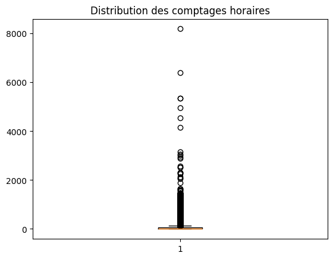

```python
import matplotlib.pyplot as plt

plt.boxplot(df_comptages["Comptage horaire"])
plt.title("Distribution des comptages horaires")
```

```python
quartiles = df_comptages["Comptage horaire"].quantile([0.25, 0.5, 0.75, 1])
quartiles
```

```
0.25       0.0
0.50      11.0
0.75      55.0
1.00    8190.0
Name: Comptage horaire, dtype: float64
```

Il semblerait qu'il y ait beaucoup de valeur supérieurs au troisième quartile. Après vérification de certaines données, il semblerait qu'il s'agit d'erreur, la valeur la plus haute est daté au 08 aout 2022 hors il n'y a pas eu d'évenement autour de cette date. Egalement lors des jeux olympiques cyclistes du 24 et 27 juillet, les comptages ne semblent pas anormaux. Dans un premier temps, la méthode classique des quartiles et de l’IQR a été envisagée pour détecter les valeurs atypiques dans les données de comptage horaire. Cependant, après analyse, nous avons constaté que cette approche ne reflétait pas totalement la réalité des données, car certaines valeurs très élevées, bien que rares, restaient incluses.

Nous avons donc pris la décision de fixer un seuil empirique à 1500 : toutes les observations dont le comptage horaire dépassait cette valeur ont été retirées du jeu de données. Ce choix me permet de filtrer les extrêmes tout en conservant la cohérence globale de la distribution.

```python
df_comptages = df_comptages[df_comptages["Comptage horaire"] < 1500]
```

```python
df_comptages
```

|  | Identifiant du compteur | Comptage horaire | Date et heure de comptage | Date du comptage | Heure du comptage |
| --- | --- | --- | --- | --- | --- |
| 0 | 101003097-100003097 | 3.0 | 2016-01-01 00:00:00 | 2016-01-01 | 0 |
| 1 | 101003097-100003097 | 6.0 | 2016-01-01 01:00:00 | 2016-01-01 | 1 |
| 2 | 101003097-100003097 | 14.0 | 2016-01-01 02:00:00 | 2016-01-01 | 2 |
| 3 | 101003097-100003097 | 14.0 | 2016-01-01 03:00:00 | 2016-01-01 | 3 |
| 4 | 101003097-100003097 | 6.0 | 2016-01-01 04:00:00 | 2016-01-01 | 4 |
| ... | ... | ... | ... | ... | ... |
| 7069349 | 300030271-353356061 | 76.0 | 2025-04-09 15:00:00 | 2025-04-09 | 15 |
| 7069350 | 300030271-353356061 | 95.0 | 2025-04-09 16:00:00 | 2025-04-09 | 16 |
| 7069351 | 300030271-353356061 | 227.0 | 2025-04-09 18:00:00 | 2025-04-09 | 18 |
| 7069352 | 300030271-353356061 | 182.0 | 2025-04-09 19:00:00 | 2025-04-09 | 19 |
| 7069353 | 300030271-353356061 | 233.0 | 2025-04-09 23:00:00 | 2025-04-09 | 23 |

7069325 rows × 5 columns

```python
# Visualisation finale des df

# Comptages
print("Comptages :")
display(df_comptages.head())

# Compteurs
print("Compteurs :")
df_compteurs.head()
```

```
Comptages :
```

|  | Identifiant du compteur | Comptage horaire | Date et heure de comptage | Date du comptage | Heure du comptage |
| --- | --- | --- | --- | --- | --- |
| 0 | 101003097-100003097 | 3.0 | 2016-01-01 00:00:00 | 2016-01-01 | 0 |
| 1 | 101003097-100003097 | 6.0 | 2016-01-01 01:00:00 | 2016-01-01 | 1 |
| 2 | 101003097-100003097 | 14.0 | 2016-01-01 02:00:00 | 2016-01-01 | 2 |
| 3 | 101003097-100003097 | 14.0 | 2016-01-01 03:00:00 | 2016-01-01 | 3 |
| 4 | 101003097-100003097 | 6.0 | 2016-01-01 04:00:00 | 2016-01-01 | 4 |

```
Compteurs :
```

|  | Identifiant du compteur | Nom du compteur | Date d'installation du site de comptage | Coordonnées géographiques |
| --- | --- | --- | --- | --- |
| 360144 | 101003096-100003096 | 97 avenue Denfert Rochereau SO-NE | 2012-02-21 | 48.83511,2.33338 |
| 368928 | 101003099-100003099 | 100 rue La Fayette O-E | 2012-02-21 | 48.87813,2.3497 |
| 377712 | 101007049-100007049 | 28 boulevard Diderot O-E | 2013-01-17 | 48.846028,2.375429 |
| 386496 | 102007049-100007049 | 28 boulevard Diderot E-O | 2013-01-17 | 48.846028,2.375429 |
| 789504 | 101036718-100036718 | 39 quai François Mauriac SE-NO | 2017-07-11 | 48.83436,2.377 |

```python
df_comptages.to_csv("comptages.csv", sep=";", index=False)
df_compteurs.to_csv("compteurs.csv", sep=";", index=False, encoding='utf-8')
```

Afin de pouvoir enrichir nos recherches nous allons recuperer des données météo por voir comment cela influence les comptages de vélos.